# Effective Data Visualization

Steve Elston

01/10/2022

# Soving Data Science Coding Problems

Correctly using programming environments is a core data science skill; Python, R, SQL,…..

- Read the documentation!
  - Package documentation should be your first stop
  - Do you know what all the arguments do?
  - Are there examples/User Guides?
- Search for answers online
  - Search package Wiki
  - Search reliable third party sources - e.g. StackOverflow
  - Chances are some package nija has already answered the question you have
- Trial and error
  - Sometimes you just have to test several possibilities
  - Work with the smallest unit of code to reproduce the problem
  - Use a small subset of the data - check types and formats
  - Try a symbolic debugger

# Effective Visualization for Exploration and Communications

Visualization is primarily a form of communications

- To be effective, visualization must be:
  - Clear
  - Well Organized
  - Simple
- Creating effective visualization is difficult
  - Requires significant effort
  - Try lots of ideas, fail fast, keep successful results

# Visualizing Large Complex Data is Difficult

**Problem:** Modern data sets are growing in size and complexity

- **Goal:** Understand key relationships in large complex data sets
- **Difficulty:** Large data volume
  - Modern computational systems have massive capacity
  - Example: Use map-reduce algorithms on cloud clusters
- **Difficulty:** Large numbers of variables
  - Huge number of variables with many potential relationships
  - **Dealing with complexit is the hard part!**

# Limitation Scientific Graphics

All scientific graphics are limited to a **2-dimensional projection**

- But, complex data sets have a great many dimensions
- We need methods to project large complex data onto 2-dimensions
- Generally, multiple views are required to understand complex data sets
  - Don’t expect one view to show all important relationships
  - Develop understanding over many views
  - Try many views, don’t expect most to be very useful

# Why is Perception Important?

- **Goal:** Communicate information visually
- Visualization technique maximize the information a viewer perceives
- Limits of human perception are a significant factor in understanding complex relationships
- Can apply results of the considerable research on human perceptions for data visualization

# Use Aesthetics to Improve Perception

- We explore aesthetics to improve perception
- We take a very broad view of the term ‘aesthetic’ here
- A plot aesthetics is any property of a visualization which highlight some aspect of the data relationships
- Aesthetics are used to project additional dimensions of complex data onto the 2-dimensional plot surface

# Over-plotting

**Over-plotting** occurs in plots when the markers lie one on another.

- Common, even in relatively small data sets
- Scatter plots can look like a blob and be completely uninterpretable
- Over-plotting is a significant problem in EDA and presentation graphics

# Dealing with Over-plotting

What can we do about over-plotting?

- **Marker transparency:** so one can see markers underneath; useful in cases with minimal overlap of markers
- **Marker size:** smaller marker size reduces over-plotting within limits
- **Adding jitter:** adding a bit of random **jitter** to variables with limited number of values
- **Down sample:** visualize a subset of the full data

# Example of Overplotting

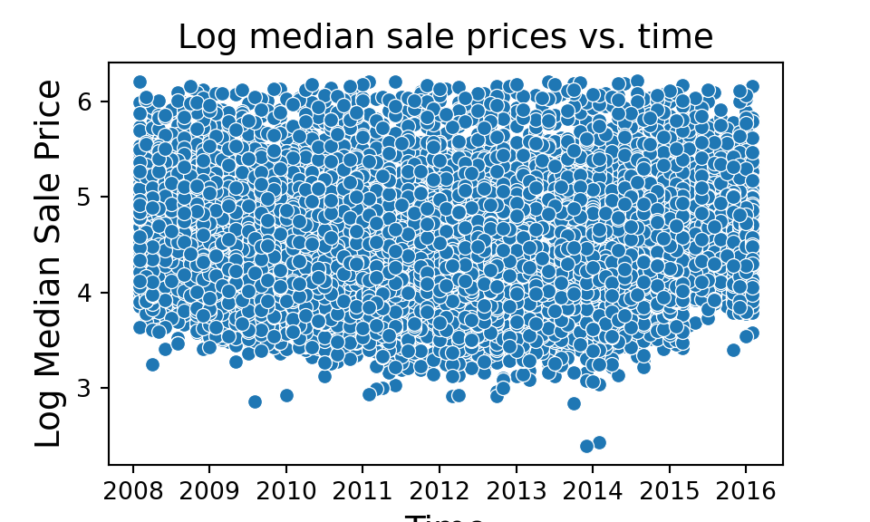

# Use Transparency, Marker Size, Downsampling

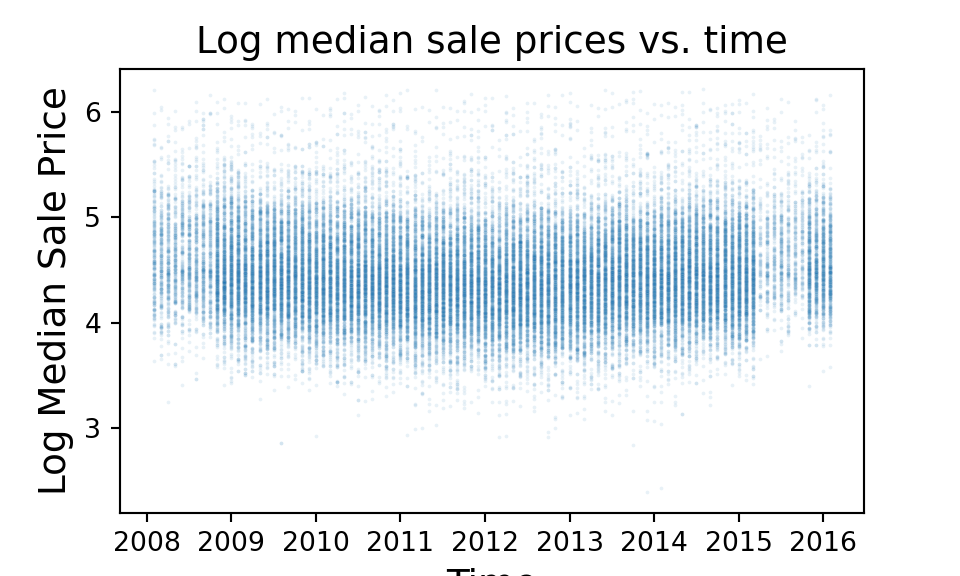

# Alternatives to avoid over-plotting for truly large data sets

- **Hex bin plots:** the 2-dimensional equivalent of the histogram
  - Frequency of values is tabulated into 2-dimensional hexagonal bins
  - Displayed using a sequential color palette
- **2-d kernel density estimation plots:** natural extension of the 1-dimensional KDE plot
  - Good for moderately large data
- **Heat map:** values of one variable against another
  - Categorical (count) or continuous variables
  - Carefully choose color pallet, sequential or divergent
- **Mosaic plots:** display multidimensional count (categorical) data
  - Uses tile size and color to project multiple dimensions
  - 2-d equivalent of a multi-variate bar chart

# Hexbin Plot

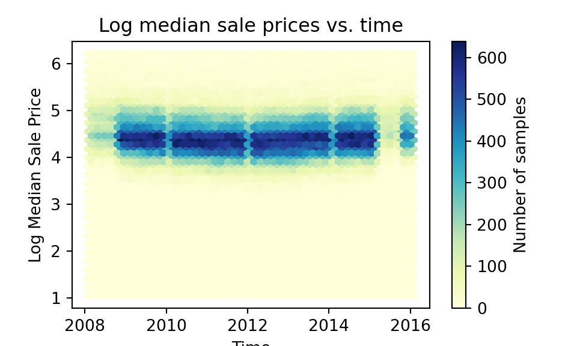

# Countour Plot

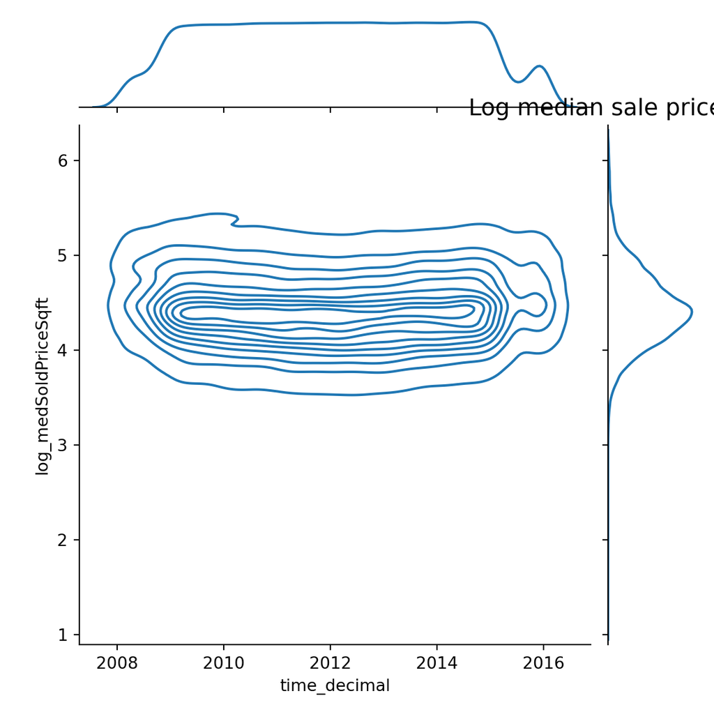

# Other Methods to Display Large Data Sets

Sometimes a **creative alternative** is best

- Often situation specific; many possibilities
- Finding a good one can require significant creativity!
- Example, choropleth for multidimensional geographic data
- Example, time series of box plots

# Time Series of Box Plots

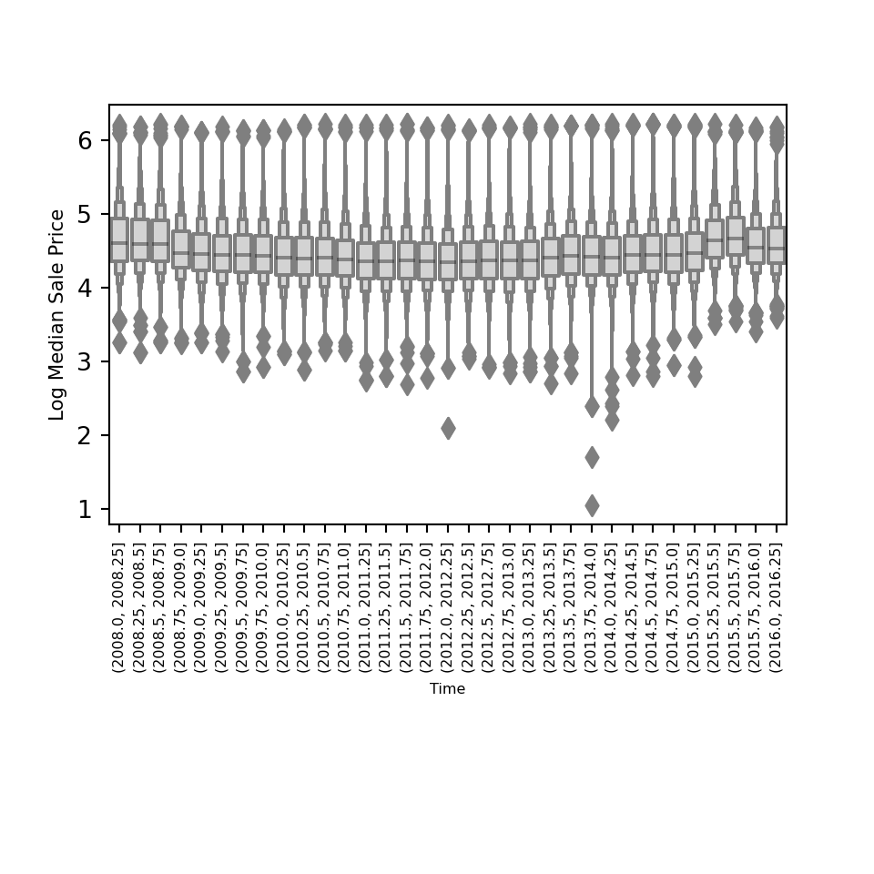

# bivariate measures

- **Pearson’s correlation** looks for a **linear** relationship
- **Spearman’s rank correlation** is Pearson’s correlation applied to **ranks** (min = rank 1, max = rank $n$)
- image source: [wikipedia.com](https://en.wikipedia.org/wiki/Anscombe%27s_quartet)

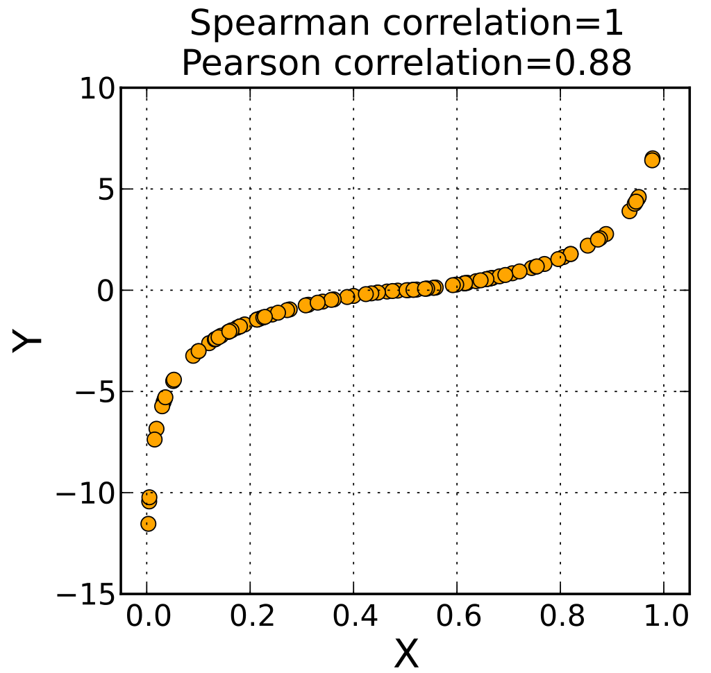

# joint plots

- this is what a 2D density plot looks like, similar to a heatmap or contour plot
- we can also imagine a 2D histogram, but visually it’s not practical
- they can resemble theoretical distributions, like the **bivariate normal distribution**
- image source: [seaborn.pydata.org/](https://seaborn.pydata.org/examples/scatterplot_matrix.html)

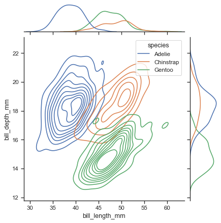

# higher dimensional data

In higher dimensions, things get more challenging, but still manageable **up to a certain point** (usually 5 or so dimensions)  
- we can use **aesthetics** to add additional dimensions to visualizations, but we quickly run out of elements  
- we can use **faceting** to break up a plot into many, but having too many plots to look at can be overwhelming

As dimensionality goes up, we need to rely on more advanced methods, but as we learn later there’s no such thing as a free lunch  
- run a ML algorithms for **dimensionality reduction**  
- use visualizations such as t-SNEs meant to deal with such situations